[figure not shown]

# Exploration

### Placed

[interactive chart not shown]

### Status Value Counts

[interactive chart not shown]

### Program Duration

[interactive chart not shown]

### Cohort Count

[interactive chart not shown]

The cohort start dates were assigned via this logic:

- If group IN (‘a’,‘A’), cohort started the first Monday of the month
- If group IN (‘B’,‘C’), cohort started the third Monday of the month
- If cohort_tag missing, cohort started July 2020, group A*.

NOTE*: There were 8 missing entries for cohort_tag. I populated those with a value outside the possible range: July 2020, group A. There are also two inaccurate values: start dates of 2021-10-04, unless those people have agreed to start on that future date.

[interactive chart not shown]

# Approach

### pathrise_status & censored outcomes

First let’s discuss the attribute pathrise_status. This entry contains information about the employment outcome or indicates if the employment outcome in censored.

## Lost to follow up

**‘MIA’** : These entries indicate the employment outcome is currently unknown. This data would be useful if we knew the date the customer became MIA. We do know these individuals were not hired prior to becoming MIA, but we do not know the amount of time each individual was in “treatment”.

## Break in treatment

**‘Break’** : Like those who are MIA, individuals on a break could provide some useful information if we knew the date the break was initiated.

## No treatment received

#### **Issues**:

Break length is not accounted for. No matter the status of an indivudual, they may have previously held the MIA or Break status. This dataset does not indicate customers’ status history. This will cause measurement error in program_duration_days, which will degrade model performance.

### Missingness

#### Percent of Missing Data by Attribute

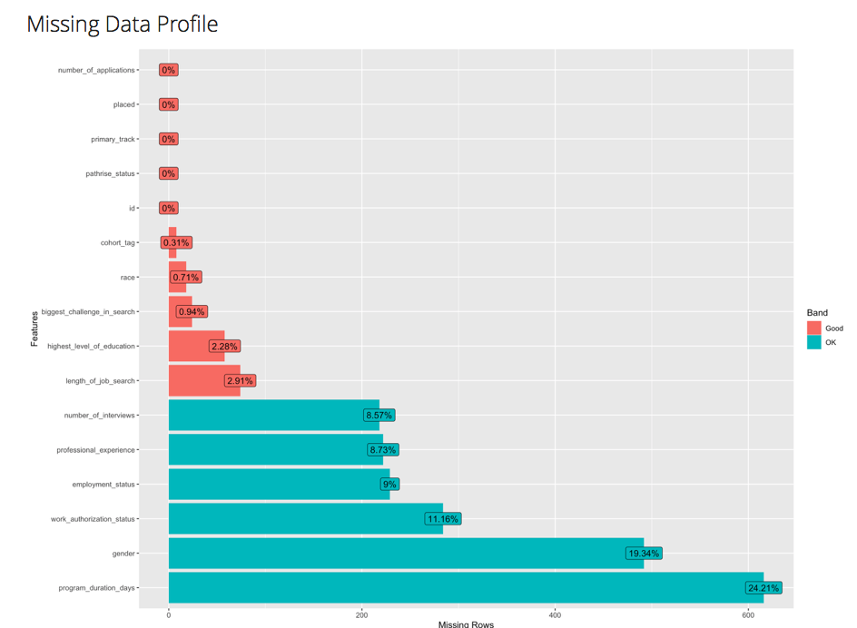

We know why program_duration_days has missing values (they are associated with Active customers). Missing gender attributes is unsurprising, though unfortunate. We know from the rather shameful history of labor statistics in the United States, and the tech industry in particular, that gender may play a role in hiring decisions–illegal or not, consciously or not. Work authorization status is also likely an important attribute. It is more work and more money to employ a non-US-citizen if they will require visa sponsorship or related support in order to be employed and live domestically. Professional experience and employment status are of course important, as well. More experience is generally better (there are exceptions, some correlated with age discrimination, some due to pay expectations), and being currently employed is a positive signal of desireability.

### Approach

With more time, I would examine the missingness patterns of the attributes. When missing or censored data is correlated with the outcome of interest, this will lead to bias in model estimates. For example, if individuals withdraw from the program because they were hired externally, this means they were “hireable” to some degree, which likely corresponds to an increased probability of being placed while in the program. But, this could mean that the best candidates for this program are not the most hireable on paper. In fact, I would expect the ‘biggest challenge in search’ to be predictive of final program status, which I would love to explore further.

## Issues

1. Significant missingness in important attributes
2. The dates of censored data are censored for both MIA and Break
3. Closed Lost and Deferred zero-inflate the dataset with zero-day participation
4. This dataset was up to date on the date it made available to me, ‘2020-02-25’

## Assumptions (that I would not make in real life unless supported by further investigation)

1. Data is missing at random
2. MIA and Break are uncorrelated with program duration (laughable, but unavoidable under the current information and time constraints)
3. The demographics/characteristics of non-participants are uncorrelated with their expected program duration if they were to choose to participate (a checkable assumption, but I need to move along to the model)

# Model Summary

### Model Summary

```
Call:
aareg(formula = surv_placed ~ employment_status + number_of_applications,
    data = dat_complete)

  n= 2244
    332 out of 332 unique event times used

                                        slope      coef se(coef)       z
Intercept                            5.32e-03  8.33e-04 1.12e-04  7.4600
employment_statusEmployed Full-Time -2.75e-04 -4.38e-05 1.27e-04 -0.3450
employment_statusEmployed Part-Time  1.79e-05 -1.04e-05 1.38e-04 -0.0756
employment_statusStudent             3.85e-04  2.14e-05 1.21e-04  0.1760
employment_statusUnemployed          6.18e-04  5.69e-05 1.24e-04  0.4590
number_of_applications               3.11e-06  5.40e-07 6.43e-07  0.8400
                                           p
Intercept                           8.96e-14
employment_statusEmployed Full-Time 7.30e-01
employment_statusEmployed Part-Time 9.40e-01
employment_statusStudent            8.60e-01
employment_statusUnemployed         6.46e-01
number_of_applications              4.01e-01

Chisq=2.28 on 5 df, p=0.809; test weights=aalen
```

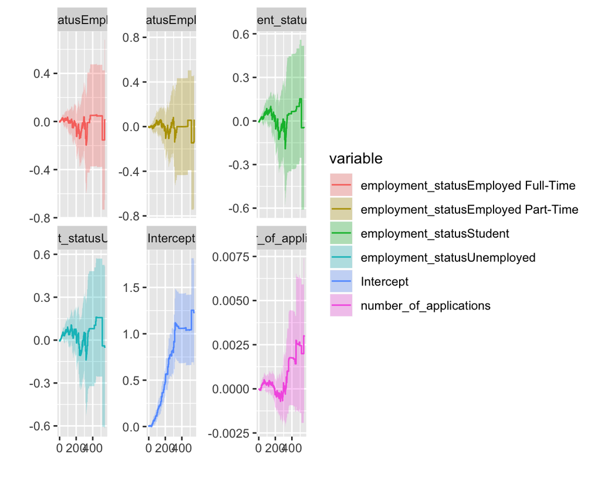

### Recommendations

The most significant factors for a successful job search are unlikely to be captured in this dataset. Given the minimal impact of the covariates presented here, this analysis should not be used to guide decisions regarding who to accept into the program, or who to monitor/assist more closely. Those decisions come with experience, and should not depend on the same superficial attributes that jobs screen on–the same attributes that perpetuate discrimination and hinder career change–and lead individuals to seeking guidance from companies like Pathrise. Characteristics like drive, determination, persistence, and desire are likely to be far more telling than the demoraphics and simple resume summaries analyzed here.